# Lecture 9 — R Graphics and Statistics: Making Data Talk

### 📊 Stacked bars: composition inside one bar

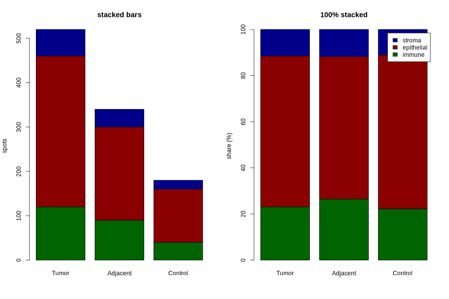

- **stacked bar → composition inside one bar**: one bar split by group; 100% stacked shows shares
- Read both how tall the bar is and how the inside is split

**Note**

Stacked bars show composition. Read two things: how tall the bar is, and how the inside is split. A tall bar and a large share are different claims.

8. The Common Plots

### 🧇 Venn diagram: how much two sets share

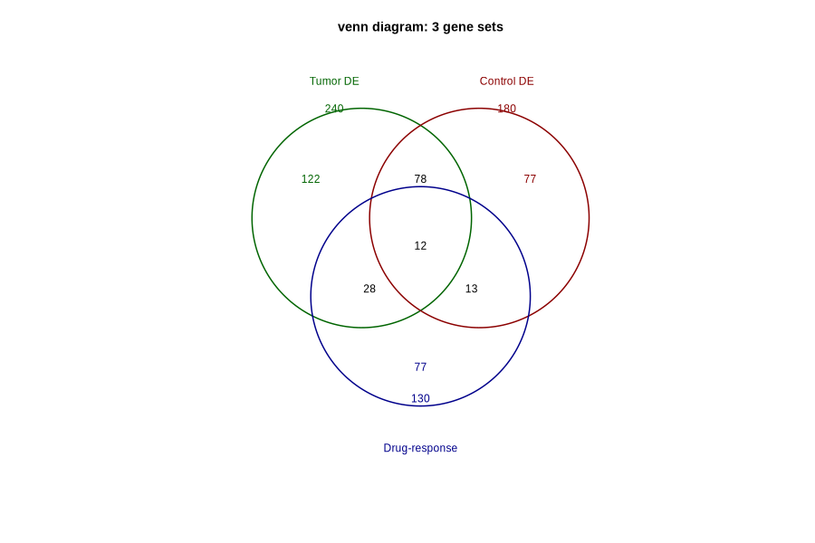

- **Venn → how much two or three sets share**: each region is a count of genes
- Two sets are readable; three are the limit

**Note**

A Venn answers “how much is shared”. Two sets are readable; three are the limit, and four sets stop being a picture of the counts.

8. The Common Plots

### 🧬 UMAP / tSNE: cells flattened to a plane

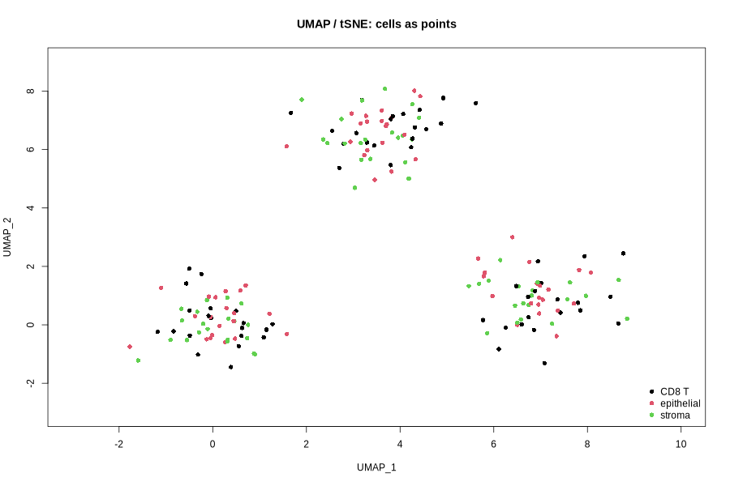

- **UMAP / tSNE → cells flattened to a plane**: one dot per cell; position is learned similarity, colour is the label
- Far apart means different expression profiles — not far apart in the tissue

**Note**

UMAP and tSNE are dimension reduction: neighbourhood, not geography. A spot map keeps the real x and y; a UMAP does not.

8. The Common Plots

### 🧮 Correlation matrix: r for every pair

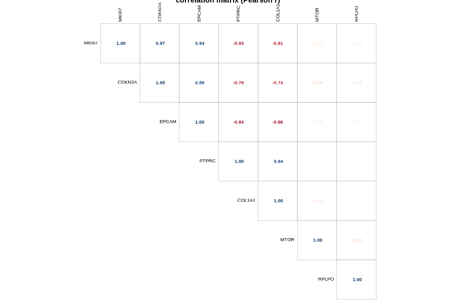

- **correlation matrix → r for every pair**: one cell per pair of genes, value is r
- Read sign and size together; the diagonal is 1.00 by definition

**Note**

Read sign and size together. The colours are a palette choice; the numbers are the claim, so read the matrix with the values in it.

8. The Common Plots

### B. Spatial & DE plots

- **spot map** — real x, y in tissue, colour = expression
- **violin** — the whole distribution, per sample
- **volcano** — one dot per gene: effect size against significance
- **heatmap** — gene × sample as coloured cells

**Note**

The same shapes, on data that carries a gene name, a sample name, or a position in the tissue.

8. The Common Plots

### 🗺️ Spot map: expression on a tissue

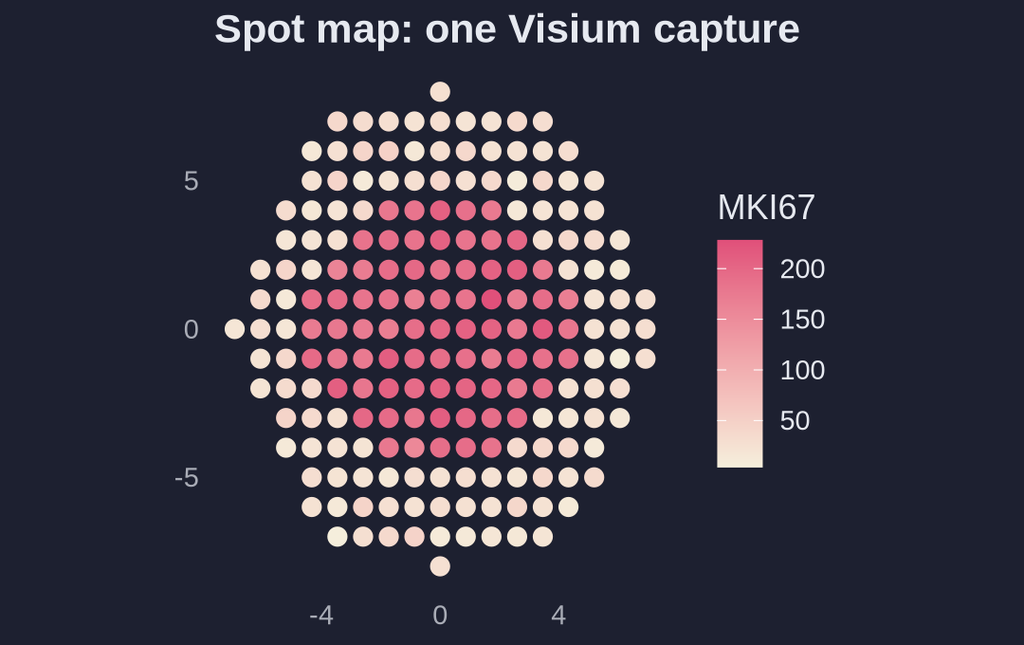

```r
ggplot(spots, aes(x = x, y = y)) + geom_point(aes(colour = expr)) + coord_equal()
```

- **spot map → expression on a tissue**: one dot per spot; x, y are positions, colour is expression
- The map keeps real x, y in the tissue

**Note**

`coord_equal()` makes 1 unit of x the same length as 1 unit of y, so a round tissue stays round.

8. The Common Plots

### 🎻 Violin: the whole distribution, per group

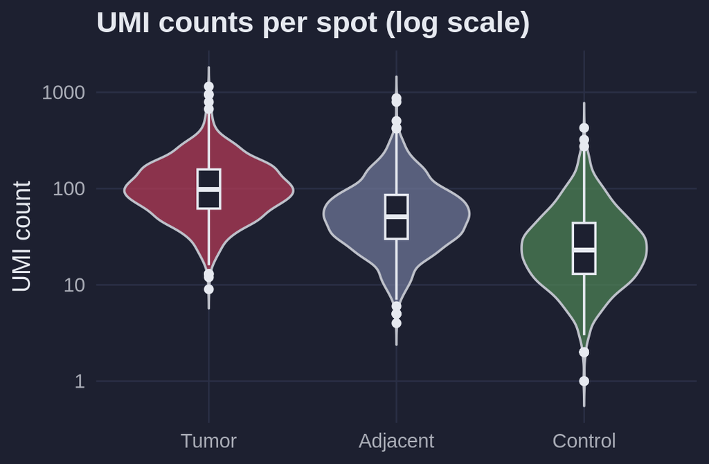

```r
ggplot(umi, aes(x = sample, y = umi, fill = sample)) +
  geom_violin(trim = FALSE) + geom_boxplot(width = 0.12) + scale_y_log10()
```

- **violin → whole distribution, per group**: mirrored density; width is how many sit at that value
- The box inside is the boxplot, drawn inside the curve

**Note**

A violin is a mirrored density. The box inside it is the boxplot from the box slide, drawn inside the curve.

8. The Common Plots

### 🌋 Volcano: effect size against significance

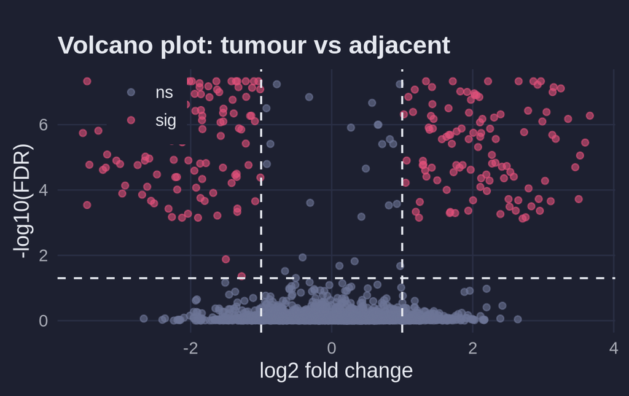

```r
ggplot(de, aes(x = log2FC, y = -log10(padj), colour = state)) +
  geom_point() + geom_hline(yintercept = -log10(0.05), linetype = "dashed") +
  geom_vline(xintercept = c(-1, 1), linetype = "dashed")
```

- **volcano → effect size against significance**: one dot per gene; x is effect, y is −log10(FDR)
- The dashed lines are the thresholds the authors chose

**Note**

A volcano has thresholds drawn on it. The dashed lines are the cut the authors chose, not a property of the data.

8. The Common Plots

### 🟥 Heatmap: one cell per gene × sample

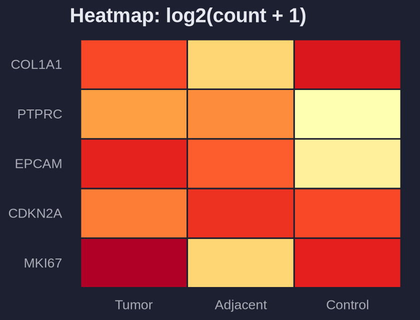

```r
ggplot(heat, aes(x = sample, y = gene, fill = value)) +
  geom_tile() +
  scale_fill_distiller(palette = "YlOrRd")
```

**Note**

8. The Common Plots

### ⚡ Q1: Control vs tumor UMI — you want centre, spread, outliers per group. Which plot?

- **A.** bar
- **B.** box plot
- **C.** scatter
- **D.** histogram

8. The Common Plots

### ✅ **B** — box plot

- **A** one bar per group; the spread behind it is hidden.
- **B** one box per group: centre, spread, outliers on one axis.
- **C** needs two numbers per spot; here there are groups only.
- **D** bins one column; it does not separate groups.

One box per group, all on one axis.

8. The Common Plots

### ⚡ Q2: 2000 genes, log2FC + FDR per gene. Which plot?

- **A.** volcano
- **B.** heatmap
- **C.** violin
- **D.** stacked bar

8. The Common Plots

### ✅ **A** — volcano

```r
ggplot(de, aes(x = log2FC, y = -log10(padj))) + geom_point()
```

- **A** x is effect, y is significance — the two columns you have.
- **B** needs genes by samples; here there are no samples.
- **C** needs one value per group; here there are 2000 genes.
- **D** shows shares in one bar; here there is no share.

One dot per gene.

8. The Common Plots

### ⚡ Q3: Expression values for genes by samples. Which plot?

- **A.** volcano
- **B.** violin
- **C.** heatmap
- **D.** Venn

8. The Common Plots

### ✅ **C** — heatmap

```r
ggplot(heat, aes(x = sample, y = gene, fill = value)) +
  geom_tile()
```

- **A** needs log2FC and FDR; here there is one value per pair.
- **B** shows one distribution per group; here there are genes by samples.
- **C** one cell per (gene, sample); colour is the value.
- **D** shows shared counts between sets; here there are no sets.

Read the scale bar with the matrix.

## 9. Reading a ggplot2 Call

1. Review from Lecture 8

2. Descriptive Statistics

3. Shape, Distribution & Normality

4. p-value & Statistical Tests

5. Correlation & Regression

6. Statistics Practice

7. From Numbers to Figures

8. The Common Plots

**9. Reading a ggplot2 Call**

10. Export for Publication

11. Graphics Practice

9. Reading a ggplot2 Call

### 🧱 The problem: `long` — one row per gene × sample

```r
long <- data.frame(
  gene = rep(c("MKI67", "CDKN2A", "EPCAM"), each = 3),
  sample = rep(c("Tumor", "Adjacent", "Control"), 3),
  tpm = c(58, 12, 4, 31, 9, 2, 44, 17, 6)
)
```

- ggplot2 needs **long** data: one row per gene × sample, one column per variable. 3 genes × 3 samples = 9 rows.

9. Reading a ggplot2 Call

### 🧱 Load the lib: ggplot2 + colours

```r
library(ggplot2)

cols <- c(Tumor = "red", Adjacent = "orange", Control = "blue")
```

- `library(ggplot2)` loads the grammar; `cols` names one colour per sample for later.

9. Reading a ggplot2 Call

### 🧱 `ggplot(long, aes(...))` — data and mapping, no drawing yet

```r
# run the two slides above first (long, ggplot2)
ggplot(long, aes(x = sample, y = tpm, fill = sample))
```

- `ggplot()` names the data; `aes()` says which column is x, y, colour. No picture yet.

9. Reading a ggplot2 Call

### 🧱 Step 2: + `geom_col()` — the bars

```r
# run the steps above first (long, ggplot2, cols)
ggplot(long, aes(x = sample, y = tpm, fill = sample)) +
  geom_col()
```

- `geom_*` is what is drawn: bars, height is `tpm`.

9. Reading a ggplot2 Call

### 🧱 Step 3: + `facet_wrap()` — one panel per gene

```r
ggplot(long, aes(x = sample, y = tpm, fill = sample)) +
  geom_col() +
  facet_wrap(~ gene, scales = "free_y")
```

- Each panel is one gene; `free_y` gives each panel its own y-axis.

9. Reading a ggplot2 Call

### 🧱 Step 4: + `scale_fill_manual()` — the colours

```r
ggplot(long, aes(x = sample, y = tpm, fill = sample)) +
  geom_col() +
  facet_wrap(~ gene, scales = "free_y") +
  scale_fill_manual(values = cols)
```

- `scale_*` sets the colour range; here the three sample colours.

9. Reading a ggplot2 Call

### 🧱 Step 5: + `coord_cartesian()` — the axis limits

```r
ggplot(long, aes(x = sample, y = tpm, fill = sample)) +
  geom_col() +
  facet_wrap(~ gene, scales = "free_y") +
  scale_fill_manual(values = cols) +
  coord_cartesian(ylim = c(0, 60))
```

- Fixes the y-axis to 0–60, so panels start at the same base.

9. Reading a ggplot2 Call

### 🧱 Step 6: + `labs()` — the labels

```r
ggplot(long, aes(x = sample, y = tpm, fill = sample)) +
  geom_col() +
  facet_wrap(~ gene, scales = "free_y") +
  scale_fill_manual(values = cols) +
  coord_cartesian(ylim = c(0, 60)) +
  labs(title = "TPM", x = NULL)
```

- Adds the title; no more x-label.

9. Reading a ggplot2 Call

### 🧱 Step 7: + `theme_minimal()` — the whole call

```r
ggplot(long, aes(x = sample, y = tpm, fill = sample)) +
  geom_col() +
  facet_wrap(~ gene, scales = "free_y") +
  scale_fill_manual(values = cols) +
  coord_cartesian(ylim = c(0, 60)) +
  labs(title = "TPM", x = NULL) +
  theme_minimal()
```

- Styling only. Data, geometry, and mapping are the first three steps.

9. Reading a ggplot2 Call

### 🔀 Long data: the shape ggplot2 needs

**Wide** — 3 rows, 3 gene columns

| sample | MKI67 | CDKN2A | EPCAM |
| --- | --- | --- | --- |
| Tumor | 58 | 31 | 44 |
| Adjacent | 12 | 9 | 17 |
| Control | 4 | 2 | 6 |

**Long** — 9 rows, 3 columns

| gene | sample | tpm |
| --- | --- | --- |
| MKI67 | Tumor | 58 |
| MKI67 | Adjacent | 12 |
| MKI67 | Control | 4 |
| CDKN2A | Tumor | 31 |
| … | … | … |

```r
tidyr::pivot_longer(wide, cols = -sample,
                    names_to = "gene", values_to = "tpm")
# 3 gene columns become one gene column and one value column, 9 rows
```

`aes()` maps **columns**. One column of gene names is what `facet_wrap` splits on, and one column of values is what every gene shares.

9. Reading a ggplot2 Call

### 👁️ Envision the plot first

- Name the plot before you code it: data, geometry, mapping.
- Describe the vision in words — let AI draft the ggplot2 call.
- Read each line against your vision, run it, adjust.

Understanding the code matters because AI writes layers for you.

## 10. Export for Publication

1. Review from Lecture 8

2. Descriptive Statistics

3. Shape, Distribution & Normality

4. p-value & Statistical Tests

5. Correlation & Regression

6. Statistics Practice

7. From Numbers to Figures

8. The Common Plots

9. Reading a ggplot2 Call

**10. Export for Publication**

11. Graphics Practice

10. Export for Publication

### 💾 The problem: a figure on screen is not a file

- What you see in R is temporary. Journals, slides, and collaborators need a saved file.

10. Export for Publication

### 💾 `ggsave()` writes it

```r
ggsave("volcano.pdf", p_vol, width = 5.4, height = 3.4)
```

- One line: the file, the plot object, the print size in inches.

10. Export for Publication

### 💾 Why both PDF and PNG?

```r
ggsave("volcano.pdf", p_vol, width = 5.4, height = 3.4)
ggsave("volcano_300.png", p_vol, width = 5.4, height = 3.4, dpi = 300)
```

- **PDF** — vector: edit in Illustrator, lossless for publication.
- **PNG** — pixels: easy preview everywhere; 300 dpi for print, 72 dpi for screen.

10. Export for Publication

### ✅ Before a figure leaves your laptop

- The figure is sized for **print** (5.4 in), not for the screen
- Every axis label carries **units**; every panel has a letter (**A**, **B**, **C**)
- The legend states the **test** and the **threshold**: “FDR < 0.05, |log2FC| > 1”
- The palette is **colourblind-safe**, not red/green only
- The **code** and the **data table** behind each figure must be saved together
- Journals ask **300 dpi** for photos, heatmaps, and spots; **vector** for line art

**Important**

A figure is a claim. If you cannot rebuild it from the code, you cannot defend it.

## 11. Graphics Practice

1. Review from Lecture 8

2. Descriptive Statistics

3. Shape, Distribution & Normality

4. p-value & Statistical Tests

5. Correlation & Regression

6. Statistics Practice

7. From Numbers to Figures

8. The Common Plots

9. Reading a ggplot2 Call

10. Export for Publication

**11. Graphics Practice**

11. Graphics Practice

### 🖥️ Graphics Practice — in the notebook

The practice moved to **`lecture-09_r_statistics_graphics_practice.ipynb`**:

- Volcano — PC9 Apatinib: effect vs BH p, 2 hits.
- Heatmap — top 6 genes × PC9 samples.

Open the notebook and Run All — real matrix, no mock figures.

## 🧠 Recap

- **the verb names the job**: `geom_*` draws, `scale_*` ranges, `coord_*` shape, `facet_*` panels
- **read a call in 3 questions**: data, geometry, mapping — envision first, draft with AI, read the code
- **the shapes**: scatter, line, bar, box, histogram, density, Venn, UMAP, then volcano, heatmap, violin, spot map
- **export**: PDF for publication (vector), PNG for preview (300 dpi)

## 🚀 What’s Next?

**Lecture 10 — Version Control, Environments & Good Coding Practices**

- the same reproducible habits: Git checkpoints, a numbered project, and clean code
- Colab + `environment.yml` so the exact toolbox rebuilds anywhere.

### 📚 Sources & Licenses

- R Core Team, **R 4.5.3** — base stats: `mean`, `median`, `sd`, `quantile`, `summary`, `t.test`, `wilcox.test`, `kruskal.test`, `aov`, `chisq.test`, `fisher.test`, `shapiro.test`, `cor.test`, `lm`, `p.adjust`, `qqnorm`, `qqline`
- Shapiro & Wilk (1965) *Biometrika* 52:591-611 · Benjamini & Hochberg (1995) *JRSS-B* 57:285-307
- Wickham, H. **ggplot2 4.0.3** — `ggplot`, `aes`, `geom_*`, `scale_*`, `facet_wrap`, `coord_equal`, `ggsave`; with **dplyr**, **tidyr** (`pivot_longer`), **ggridges**, **RColorBrewer**
- **every figure and number in this deck** is drawn in the course’s `R_tutorial` env (R 4.5.3, ggplot2 4.0.3, ggridges 0.5.7) on `png()` / `pdf()` devices, fixed seed
- Course data: **GSE129221** — Song et al. (2019) Cancer Cell Int 19:117
- **p-value meme** (section 4) — FB: `@Statisticss` · IG: `@StatisticsForYou`; image via Google Images: [encrypted-tbn0.gstatic.com](https://encrypted-tbn0.gstatic.com/images?q=tbn:ANd9GcRXpp3pINnzFSvCjsztyHpUuEUrASfQBQ7KrqcRq2yvQBfF1ofyayYX-v_O&s=10)
- **Gulls on a bent railing** (section 5, “Correlation is not causation”) — photo via X: [pbs.twimg.com/media/FAW2hMeWEAAfcvm](https://pbs.twimg.com/media/FAW2hMeWEAAfcvm?format=webp&name=large)
- Deck: Quarto 1.10.19 · revealjs · `slides.css`

## Thank You!

A reviewer sees your **figures** before your **statistics**.

Make both tell the same **true story**.